# Machine Learning Course Project

Norma Ruiz

20-oct-2015

## Introduction

Using devices such as Jawbone Up, Nike FuelBand, and Fitbit it is now possible to collect a large amount of data about personal activity relatively inexpensively. In this project the goal is to use data from accelerometers on the belt, forearm, arm, and dumbell of 6 participants. They were asked to perform barbell lifts correctly and incorrectly in 5 differente ways. The goal is to predict the manner in which they did the exercise. This is the “classe” variable in the training set, which can take the values: A, B, C, D, E, with the meanings:  
- Class A = exactly according to the specification  
- Class B = throwing the elbows to the front  
- Class C = lifting the dumbbell only halfway  
- Class D = lowering the dumbbell only halfway  
- Class E = throwing the hips to the front  
Source: Velloso, E.; Bulling, A.; Gellersen, H.; Ugulino, W.; Fuks, H. Qualitative Activity Recognition of Weight Lifting Exercises. Proceedins of 4th International Conference in Cooperation with SIGCHI (Augmented Human ’13). Stuttgart, Germany: ACM SIGCHI, 2013.  
The results of these measurements were collected in a dataset with 160 variables and 19,622 observations. I will use this data to build a model capable of determine how well the exercise was done (variable “classe”). There is another dataset with 20 observations (without the classe variable) that I will use to apply my model to predict the class.

## PreProcessing

Read the data

```r
library(caret)
setwd("~/Documents/NRS_iMAC/norma_2015/infomedia/data science/8 Practical Machine Learning/course project")
pmltrain <- read.csv("pml-training.csv",na.strings=c("","NA","#DIV/0!"))
pmltest  <- read.csv("pml-testing.csv", na.strings=c("","NA","#DIV/0!"))
```

During the exploratory data analysis I discovered that there are many missing values, so I will exclude those columns having more than 10% of missing values. I will also exclude columns with an absolute correlation factor > 0.9, Finally I exclude the first 7 columns of the data since they are irrelevant for the prediction purposes. After this reduction, there are 45 predictor variables available for the analysis, plus the response variable **classe**.

Split the data: training set and test set for my model.

```r
dim(pmltrain)
```

```
## [1] 19622   160
```

```r
na_count <- apply(pmltrain, 2, function(x) sum(is.na(x)))
cols <- names(which(na_count/dim(pmltrain[1])< 0.1, arr.ind=T))
train_new <- pmltrain[,cols]
train_new <- train_new[, -(1:7)]
train_cor <- cor(subset(train_new, select = -classe))
high_corr  <- findCorrelation(train_cor, cutoff=0.9)
train_new <- train_new[, -high_corr]
dim(train_new)
```

```
## [1] 19622    46
```

```r
inTrain = createDataPartition(train_new$classe,p=3/4)[[1]]
trn  <- train_new[ inTrain,] # 75% para entrenar
tst  <- train_new[-inTrain,] # 25% para probar
dim(trn)
```

```
## [1] 14718    46
```

```r
dim(tst)
```

```
## [1] 4904   46
```

## Variable Selection

I built a model using **random forest** to select the 20 most important predictor variables, in order to have a simple model.

```r
library(doMC)
registerDoMC(cores=3)
model_rf <- train(classe ~ ., data=trn, method="rf")
```

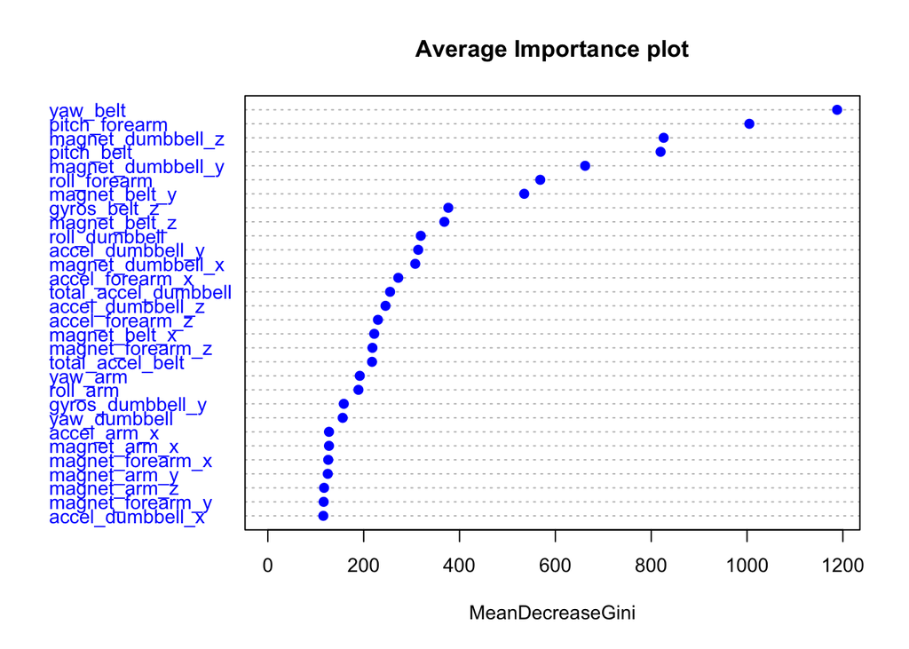

```r
varImpPlot(model_rf$finalModel, main="Average Importance plot",
           col="blue", pch =19, cex=0.9)
```

```r
top20 <- varImp(model_rf)[[1]]
x <- order(-top20$Overall)
top20vars <- row.names(top20)[x][1:20]
trn20 <- cbind(trn[,top20vars], trn$classe)
names(trn20)[21] <- "classe"
```

## Training

Lets train 2 different models using the training data with 20 predictor variables: boosting(gbm) and random forest(rf). The accuracy for each model is: boosting accuracy=0.9492; random forest accuracy=0.99 (this numbers can change a little bit each next execution).

```r
# first model - boosting
train_gbm <- train(classe ~ ., data=trn20, method="gbm", verbose=F)
pred_gbm  <- predict(train_gbm, newdata=tst)
confusionMatrix(pred_gbm, tst$classe)
```

```
## Confusion Matrix and Statistics
##
##           Reference
## Prediction    A    B    C    D    E
##          A 1376   36    0    0    0
##          B   15  864   26    3   12
##          C    4   39  802   30   14
##          D    0    4   22  763   12
##          E    0    6    5    8  863
##
## Overall Statistics
##
##                Accuracy : 0.9519
##                  95% CI : (0.9455, 0.9577)
##     No Information Rate : 0.2845
##     P-Value [Acc > NIR] : < 2.2e-16
##
##                   Kappa : 0.9391
##  Mcnemar's Test P-Value : NA
##
## Statistics by Class:
##
##                      Class: A Class: B Class: C Class: D Class: E
## Sensitivity            0.9864   0.9104   0.9380   0.9490   0.9578
## Specificity            0.9897   0.9858   0.9785   0.9907   0.9953
## Pos Pred Value         0.9745   0.9391   0.9021   0.9526   0.9785
## Neg Pred Value         0.9946   0.9787   0.9868   0.9900   0.9906
## Prevalence             0.2845   0.1935   0.1743   0.1639   0.1837
## Detection Rate         0.2806   0.1762   0.1635   0.1556   0.1760
## Detection Prevalence   0.2879   0.1876   0.1813   0.1633   0.1799
## Balanced Accuracy      0.9881   0.9481   0.9583   0.9699   0.9765
```

```r
# second model - random forest
train_rf  <- train(classe ~ ., data=trn20, method="rf")
pred_rf   <- predict(train_rf, newdata=tst)
confusionMatrix(pred_rf, tst$classe)
```

```
## Confusion Matrix and Statistics
##
##           Reference
## Prediction    A    B    C    D    E
##          A 1395    7    0    0    0
##          B    0  937   11    0    0
##          C    0    5  839   10    2
##          D    0    0    5  792    1
##          E    0    0    0    2  898
##
## Overall Statistics
##
##                Accuracy : 0.9912
##                  95% CI : (0.9882, 0.9936)
##     No Information Rate : 0.2845
##     P-Value [Acc > NIR] : < 2.2e-16
##
##                   Kappa : 0.9889
##  Mcnemar's Test P-Value : NA
##
## Statistics by Class:
##
##                      Class: A Class: B Class: C Class: D Class: E
## Sensitivity            1.0000   0.9874   0.9813   0.9851   0.9967
## Specificity            0.9980   0.9972   0.9958   0.9985   0.9995
## Pos Pred Value         0.9950   0.9884   0.9801   0.9925   0.9978
## Neg Pred Value         1.0000   0.9970   0.9960   0.9971   0.9993
## Prevalence             0.2845   0.1935   0.1743   0.1639   0.1837
## Detection Rate         0.2845   0.1911   0.1711   0.1615   0.1831
## Detection Prevalence   0.2859   0.1933   0.1746   0.1627   0.1835
## Balanced Accuracy      0.9990   0.9923   0.9885   0.9918   0.9981
```

## Combining models

Finally, I combined both models fitting a model that combine the predictors using the training data. Lets measure the accuracy of this combined model using the test data: combined accuracy=0.9904 (this number can change a little bit each execution).

```r
pred_gbm     <- predict(train_gbm, newdata=trn)
pred_rf      <- predict(train_rf, newdata=trn)
trn_dat_comb <- data.frame(GBM=pred_gbm,RF=pred_rf,classe=trn$classe)
train_comb   <- train(classe ~ ., method="rf",data=trn_dat_comb)
pred_gbm     <- predict(train_gbm, newdata=tst)
pred_rf      <- predict(train_rf, newdata=tst)
tst_dat_comb <- data.frame(GBM=pred_gbm,RF=pred_rf,classe=tst$classe)
pred_comb    <- predict(train_comb, newdata=tst_dat_comb)
confusionMatrix(pred_comb, tst$classe)
```

```
## Confusion Matrix and Statistics
##
##           Reference
## Prediction    A    B    C    D    E
##          A 1395    7    0    0    0
##          B    0  937   11    0    0
##          C    0    5  839   10    2
##          D    0    0    5  792    1
##          E    0    0    0    2  898
##
## Overall Statistics
##
##                Accuracy : 0.9912
##                  95% CI : (0.9882, 0.9936)
##     No Information Rate : 0.2845
##     P-Value [Acc > NIR] : < 2.2e-16
##
##                   Kappa : 0.9889
##  Mcnemar's Test P-Value : NA
##
## Statistics by Class:
##
##                      Class: A Class: B Class: C Class: D Class: E
## Sensitivity            1.0000   0.9874   0.9813   0.9851   0.9967
## Specificity            0.9980   0.9972   0.9958   0.9985   0.9995
## Pos Pred Value         0.9950   0.9884   0.9801   0.9925   0.9978
## Neg Pred Value         1.0000   0.9970   0.9960   0.9971   0.9993
## Prevalence             0.2845   0.1935   0.1743   0.1639   0.1837
## Detection Rate         0.2845   0.1911   0.1711   0.1615   0.1831
## Detection Prevalence   0.2859   0.1933   0.1746   0.1627   0.1835
## Balanced Accuracy      0.9990   0.9923   0.9885   0.9918   0.9981
```

## Conclusion

Since the combined model has the same accuracy as the random forest I will choose the random forest model since it is simpler than the combined model.

```r
head(getTree(train_rf$finalModel, k=1, labelVar=T))
```

```
##   left daughter right daughter         split var split point status
## 1             2              3  total_accel_belt       20.50      1
## 2             4              5     pitch_forearm      -33.95      1
## 3             6              7   accel_forearm_x      135.00      1
## 4             8              9  magnet_forearm_z      777.50      1
## 5            10             11 magnet_dumbbell_y      439.50      1
## 6            12             13 magnet_dumbbell_z     -162.00      1
##   prediction
## 1       <NA>
## 2       <NA>
## 3       <NA>
## 4       <NA>
## 5       <NA>
## 6       <NA>
```

```r
head(getTree(train_rf$finalModel, k=2, labelVar=T))
```

```
##   left daughter right daughter         split var split point status
## 1             2              3     magnet_belt_y      556.50      1
## 2             4              5 magnet_dumbbell_z      137.50      1
## 3             6              7     pitch_forearm      -26.45      1
## 4             8              9     magnet_belt_y      422.50      1
## 5            10             11     magnet_belt_z     -435.00      1
## 6            12             13      roll_forearm      104.50      1
##   prediction
## 1       <NA>
## 2       <NA>
## 3       <NA>
## 4       <NA>
## 5       <NA>
## 6       <NA>
```

```r
library(inTrees)
treeList <- RF2List(train_rf$finalModel)
exec <- extractRules(treeList, trn20)
```

```
## 3119 rules (length<=6) were extracted from the first 100 trees.
```

```r
ruleMetric <- getRuleMetric(exec, trn20, trn20$classe)
ruleMetric <- pruneRule(ruleMetric, trn20, trn20$classe)
ruleMetric <- selectRuleRRF(ruleMetric, trn20, trn20$classe)
rules <- presentRules(ruleMetric,colnames(trn20))
head(rules)
```

```
##      len freq    err
## [1,] "3" "0.771" "0.779"
## [2,] "2" "0.082" "0"
## [3,] "4" "0.084" "0.289"
## [4,] "2" "0.025" "0.448"
## [5,] "1" "0.16"  "0.583"
## [6,] "4" "0.005" "0.013"
##      condition
## [1,] "yaw_belt<=168.5 & pitch_forearm>-26.45 & magnet_dumbbell_z>-95.5"
## [2,] "yaw_belt>15.42 & yaw_belt<=153"
## [3,] "magnet_dumbbell_y>439.5 & gyros_belt_z>-0.255 & magnet_belt_z<=-290.5 & total_accel_dumbbell>5.5"
## [4,] "magnet_dumbbell_z<=-95.5 & magnet_dumbbell_y<=-566.5"
## [5,] "magnet_dumbbell_y>439.5"
## [6,] "magnet_dumbbell_z<=-88.5 & magnet_dumbbell_y<=-555.5 & magnet_belt_z>-442.5 & accel_forearm_x<=-137"
##      pred impRRF
## [1,] "C"  "1"
## [2,] "E"  "0.698054004518719"
## [3,] "B"  "0.31434884480725"
## [4,] "B"  "0.234257163772643"
## [5,] "B"  "0.0678232767460459"
## [6,] "D"  "0.0500887486522754"
```